# New image-based stuff

### Outline

So the gist of the image-based workflow is:

- `getimg()`: Load up an image or images. Similar in structure to `getspec`. So if a full path to an image is passed, it just grabs that image, but if a directory is specified it grabs everything in there as long as it’s jpeg, png, or bmp. With subdirectory options etc too of course. So all the downstream functions are built to handle either single images (a 3d RGB array), or multiple images (a list of 3d RGB arrays) gracefully, without the user having to lapply everything. That’s why if you look at the internals of the downstream functions they’re structured a bit unusually, since the top-level (user-called) bit basically just handles some defaults and light processing, before passing everything through, via `pbmclapply` or `lapply`, to an internal function that does the grunt work. And images are of class `rimg` for downstream stuff.
- `calibrate()`: (optional). Currently lets you click on points in an image or images to manually set a scale, which is stored as an attribute for later use. If the images are standardised this can be ignored and a single scale can be set later on I could also see this being expanded to accommodate more features, like automatic image alignment, in the future, but I think keep it lightweight for now.
- `classify()`: This uses k-means clustering to assign every pixel to a discrete ‘colour class’, which is necessary for various pattern analyses that exist atm. There are options to manually click on images to assign cluster centers and/or specify a reference image so that clusters are consistently assigned between homologous pattern elements between individuals. There’s always that question of ‘what is a distinct patch’ inherent in these methods of course, but that’s actually one of the cool areas where having this woven into `pavo` makes a difference. Since if you have that spectral data from your sample too you can run your RN bootstraps and actually estimate `k` with some sensory significance, all in one place. That’d be worth illustrating in the write-up/vignette but I can’t be arsed atm…
- `adjacent()` This runs John’s adjacency analysis, including his ‘edge-salience’ extension which I don’t think is quite out yet. Should be in MEE soon. The gist being that you burn through and grab all pair-wise row and column transitions between colour-classes (adjacency matrix) then you can derive a boatload of summary variables on pattern structure, like aspect ratio, element sizes, pattern complexity and density, colour diversity, transition diversity, edge salience (if you also feed in colour distances between colour categories), animal/background transition ratios etc. You can also explicitly exclude the ‘background’, or analyse it separately. The biological meaning of some of this stuff isn’t super clear, it’s more of a hypothesis-generation affair at times, but it at least gives the user a bunch of material to work with for little investment (some basic photos in addition to the specs, or even if you don’t have specs you can get most of this stuff just from photos). Then you can test all ideas about whole patterns, rather than coloru alone. E.g. Colour diversity and complexity should be similar for cryptic species and their backgrounds, ‘memorable’ signals should have low diversity and complexity, disruptively coloured things should exhibit greater edge-salience to break-up their outline etc.
- `plot.rimg()`: Can be fed raw or colour-classified images for easy plotting. In the case of colour-classified images it’ll colour the image with the mean RGB values from each cluster, which makes it easier to see if it’s grouped things as you’d expect. If it’s fed a list of images it’ll just scroll the user through them all with a keyboard-push.
- `summary.rimg()`: Spits out some summary attribute data, or plots the mean colour-values from colour classified images.

So in a broader sense I see the workflow as roughly being: Get -> Calibrate -> Classify -> Analyse (adjacency). Since it’s structured in a fairly modular way there’s plenty of scope to expand stuff in the future as need be. e.g. more calibration options, different classification tools, or further analyses. But as it stands I think it offers a cool level of functionality.

### Crappy examples

Load up.

```r
devtools::install_github('rmaia/pavo@img')
library(pavo)
```

Load an image of a butterfly, and a series of images of simulated (based on real species) model/mimic aposematic snakes

```r
# One image
papilio <- getimg(system.file("testdata/images/papilio.png", package = 'pavo'))

# Many images
snakes <- getimg(system.file("testdata/images/snakes", package = 'pavo'))
```

```
## 11 files found; importing images.
```

Some raw plots.

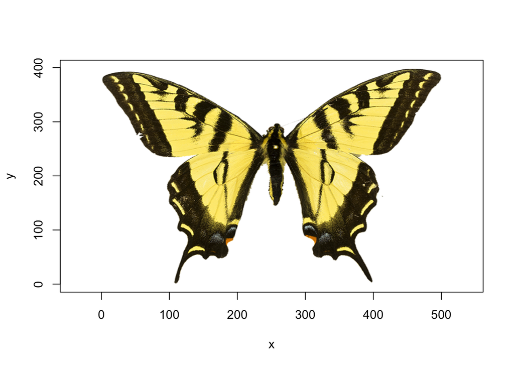

```r
plot(papilio)
```

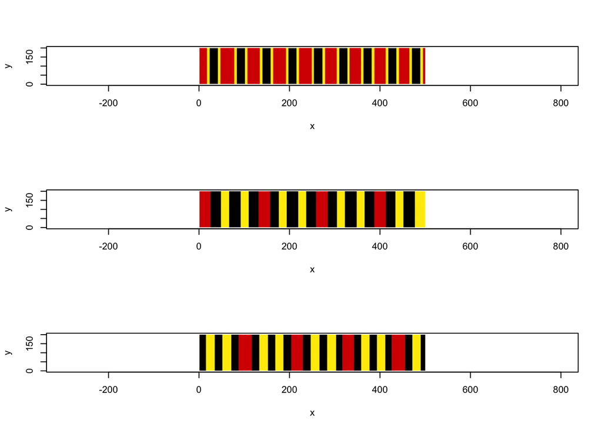

```r
# Just plot a couple of snakes since it'll otherwise it'll try to click you through. Maybe this should be an option actually..
par(mfrow = c(3,1))
plot(snakes[[1]])
plot(snakes[[4]])
plot(snakes[[8]])
```

Cool. I won’t worry about calibrating thtem since that’s interactive.

Now classify stuff.

```r
set.seed(4)

papilio_class <- classify(papilio, n_cols = 4)

snakes_class <- classify(snakes, n_cols = 3)
```

And plot again. Here’s a side-by-side example.

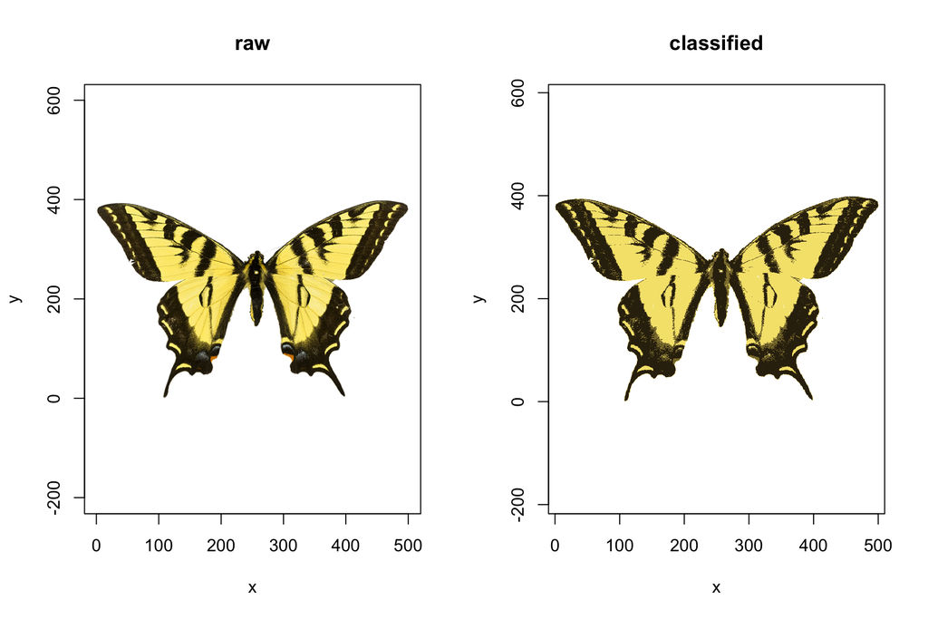

```r
par(mfrow = c(1,2))
plot(papilio, main = 'raw')
plot(papilio_class, main = 'classified')
```

You can also get a quick summary of the colours being used with `summary(plot = TRUE)`.

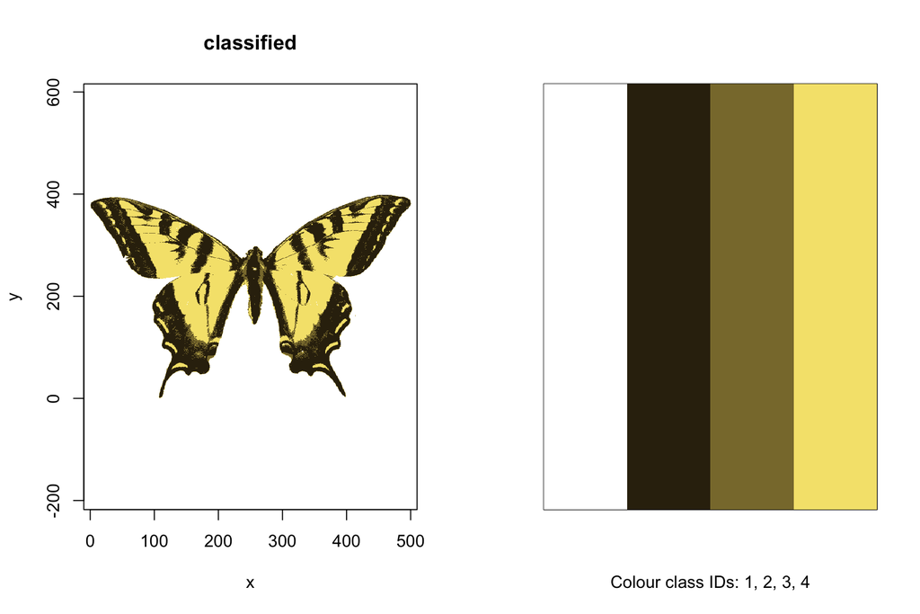

```r
par(mfrow = c(1,2))
plot(papilio_class, main = 'classified')
summary(papilio_class, plot = TRUE)
```

Now churn it through the adjacency analysis. As mentioned, you basically grid-sample the image (or just use all pixels). Here’s an undersampled example to give the idea:

[figure not shown]

```r
plot(papilio_class, main = 'classified', x_pts = 20)
```

Then you tally up all row-wise and column-wise transitions, and crunch them into various summary variables about the spatial structure of the pattern.

The actual analysis:

```r
adjacent(papilio_class, x_pts = 150, x_scale = 100)
```

```
##         k     N n_off Obs_1_2 Obs_1_3 Obs_2_3 Obs_1_4 Obs_2_4 Obs_3_4
## papilio 4 35730  4462     487     287    1694     156     910     928
##            E_1_2    E_1_3    E_2_3    E_1_4    E_2_4    E_3_4    d_t_o
## papilio 1010.644 282.0532 100.6757 902.5703 322.1621 89.90985 4294.414
##               p_1       p_2        p_3       p_4     q_1_1   q_1_2
## papilio 0.5632778 0.2010556 0.05611111 0.1795556 0.5471872 0.01363
##            q_2_2       q_1_3      q_2_3      q_3_3       q_1_4      q_2_4
## papilio 0.159194 0.008032466 0.04741114 0.01578505 0.004366079 0.02546879
##              q_3_4     q_4_4     t_1_2      t_1_3     t_2_3     t_1_4
## papilio 0.02597257 0.1529527 0.1091439 0.06432093 0.3796504 0.0349619
##             t_2_4     t_3_4         m    m_r       m_c        A  B
## papilio 0.2039444 0.2079785 0.1863271 0.2085 0.1641541 1.270148 NA
##               Sc       St        Jc        Jt m_dS s_dS cv_dS m_dL s_dL
## papilio 2.543922 2.838968 0.6359804 0.4731613   NA   NA    NA   NA   NA
##         cv_dL
## papilio    NA
```

And the list of snakes, in which case it’s all bound together in one tidy output data frame. I’ll dummy up a matrix of colour-distances to feed in for a fuller set of output stats.

```r
snakedist <- data.frame(t(combn(1:3, 2)),
           c(2, 1, 5),
           c(3, 7, 4))
names(snakedist) <- c('c1', 'c2', 'dS', 'dL')

snakedist
```

```
##   c1 c2 dS dL
## 1  1  2  2  3
## 2  1  3  1  7
## 3  2  3  5  4
```

```r
adjacent(snakes_class, x_pts = 250, x_scale = 50, coldists = snakedist)
```

```
##          k     N n_off Obs_1_2 Obs_1_3 Obs_2_3     E_1_2     E_1_3
## snake_02 3 49650  3607       2    1805    1800 1102.0663 695.64789
## snake_03 3 49650  3458      57    1740    1661  977.6750 662.13716
## snake_04 3 49650  3801      95    1995    1711 1173.4034 692.48054
## snake_05 3 49650  2200     700      NA    1500  443.5200        NA
## snake_06 3 49650  1804     804     200     800  330.4458 309.07629
## snake_07 3 49650  1703     501       2    1200  311.5029  37.97119
## snake_08 3 49650  2305     803     200    1302  441.9810 139.32158
## snake_09 3 49650  2900    1100     300    1500  575.9168 457.50400
## snake_10 3 49650  2931    1079      71    1781  947.1279 466.70761
## snake_11 3 49650  4137    2125     124    1888 1197.8297 670.75727
## snake_12 3 49650  2300    1100      NA    1200  686.9088        NA
##             E_2_3     d_t_o     p_1     p_2     p_3     q_1_1        q_1_2
## snake_02 477.6680 3531.7504 0.47168 0.32388 0.20444 0.4524471 4.028197e-05
## snake_03 248.6414 3410.8964 0.61356 0.23040 0.15604 0.5956898 1.148036e-03
## snake_04 331.9143 3760.0086 0.56748 0.27200 0.16052 0.5466062 1.913394e-03
## snake_05 656.4096 1100.0704 0.20000 0.50400 0.29600 0.1923464 1.409869e-02
## snake_06 533.8102  848.8203 0.23028 0.39772 0.37200 0.2206445 1.619335e-02
## snake_07 257.7252 1167.7431 0.11608 0.78788 0.09604 0.1102518 1.009063e-02
## snake_08 609.8143 1113.8831 0.14800 0.64780 0.20420 0.1381873 1.617321e-02
## snake_09 844.0160 1337.5712 0.23200 0.42800 0.34000 0.2183686 2.215509e-02
## snake_10 457.1923 1851.3873 0.40612 0.39784 0.19604 0.3953072 2.173212e-02
## snake_11 817.9283 2543.9993 0.34456 0.42016 0.23528 0.3205639 4.279960e-02
## snake_12 161.6256 1451.4656 0.61200 0.24400 0.14400 0.6011480 2.215509e-02
##              q_2_2        q_1_3      q_2_3      q_3_3        t_1_2
## snake_02 0.3064048 3.635448e-02 0.03625378 0.16849950 0.0005544774
## snake_03 0.2125680 3.504532e-02 0.03345418 0.12209466 0.0164835165
## snake_04 0.2543807 4.018127e-02 0.03446123 0.12245720 0.0249934228
## snake_05 0.4828600           NA 0.03021148 0.28048338 0.3181818182
## snake_06 0.3803424 4.028197e-03 0.01611279 0.36267875 0.4456762749
## snake_07 0.7713394 4.028197e-05 0.02416918 0.08410876 0.2941867293
## snake_08 0.6269285 4.028197e-03 0.02622356 0.18845921 0.3483731020
## snake_09 0.4006647 6.042296e-03 0.03021148 0.32255791 0.3793103448
## snake_10 0.3682578 1.430010e-03 0.03587110 0.17740181 0.3681337427
## snake_11 0.3806244 2.497482e-03 0.03802618 0.21548842 0.5136572395
## snake_12 0.2203223           NA 0.02416918 0.13220544 0.4782608696
##                t_1_3     t_2_3      m    m_r    m_c         A  B       Sc
## snake_02 0.500415858 0.4990297 0.3607 0.7202 0.0012 600.16667 NA 2.708735
## snake_03 0.503181029 0.4803355 0.3458 0.6878 0.0038 181.00000 NA 2.203184
## snake_04 0.524861878 0.4501447 0.3801 0.7582 0.0020 379.10000 NA 2.370881
```

[output cut: 17 more lines]

```
## snake_10 3.075844 0.9217224 1.0252813 3.798704 2.136369 0.5623944  NaN
## snake_11 3.362979 0.9507167 1.1209929 3.339135 2.109023 0.6316075  NaN
## snake_12 2.333863 0.7328971 0.7779544 3.565217 2.121320 0.5950045  NaN
##               s_dL cv_dL
## snake_02 2.1211926   NaN
## snake_03 2.1189055   NaN
## snake_04 2.1221438   NaN
## snake_05 0.7071068   NaN
## snake_06 1.5540070   NaN
## snake_07 0.7268479   NaN
## snake_08 1.4253419   NaN
## snake_09 1.5030833   NaN
## snake_10 1.0042250   NaN
## snake_11 1.0704609   NaN
## snake_12 0.7071068   NaN
```

Tons of output there, and the user doesn’t need to get all of it tbh, some of it is just there while I’m still checking it. Some NA’s in there because not all transitions are present in different species etc.

Fun stuff anyway, and will play nicely with the spectral side of things for a much richer set of information. Sorry for the lame examples here — hopefully makes the point though. I think there’s a bunch of potential anyway, and this stuff doesn’t exist in the wild.